# Módulo 3 - Medidas de importância e centralidade de vértices

Sillas Teixeira Gonzaga

Uma das principais aplicações da Análise de Redes Sociais é descrever a importância que cada vértice tem na rede por meio de métricas de centralidade. Existem vários conceitos de centralidade, portanto cabe ao autor da análise refletir sobre o que cada métrica significa para a rede que está sendo analisado. A seguir uma descrição das métricas de centralidade mais usadas:

## Degree

Corresponde à uma simples contagem da quantidade de vértices que um dado vértice está conectado por meio de uma aresta. Em outras palavras, degree centrality é a quantidade de arestas que estão conectadas a um vértice.

## Closeness

A métrica closeness centrality é o inverso da média das distâncias de um vértice para os outros vértices. Ou seja, é equivalente a medir quantas arestas em média um vértice da rede tem com outros vértices. Um vértice com grande centralidade consegue interagir com a rede como um todo com menos esforço.

## Betweenness

Para um dado vértice K, a métrica betweenness é definida como o porcentual de vezes que um vértice A precisa dele (de K) para se conectar com um vértice C por meio do trajeto mais curto possível. Isto é, de todos os menores trajetos possíveis entre todos os pares de vértices da rede, quantos passam por K?

Uma outra forma de interpretar essa métrica é como se fosse a participação de K em todos os menores caminhos possíveis da rede.

Suponha uma rede bem simples:

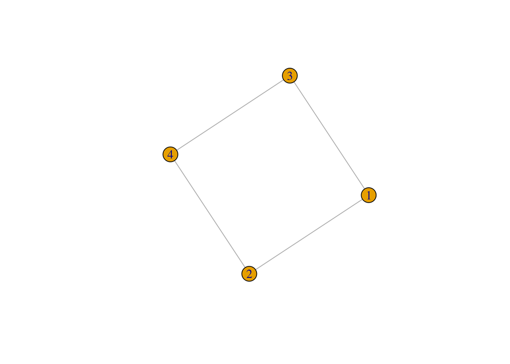

Suponha que 1 deseja transmitir uma informação para 4 pelo menor caminho possível: ele pode fazer isso escolhendo tanto o vértice 2 como o 3. Como se trata de um quadrado, o mesmo ocorre com todos os outros pares de trajetos. Dessa forma, a betweenness de todos os vértices é igual a 0,5.

```
## [1] 0.5 0.5 0.5 0.5
```

## Eigenvector (autovetor) centrality

É uma medida de conectividade que atribui valores maiores a vértices que estão conectados com mais vértices. Isto é, a centralidade de um vértice K é proporcional à soma das centralidades dos vértices que K está conectado. Assim, vértices com altos valores dessa métrica estão ligados com muitos outros vértices que, por sua vez, também estão conectados com muitos outros vértices.

No grafo abaixo, dentre os vértices A, B, ou G, qual deve possuir o menor valor da eigenvector centrality?

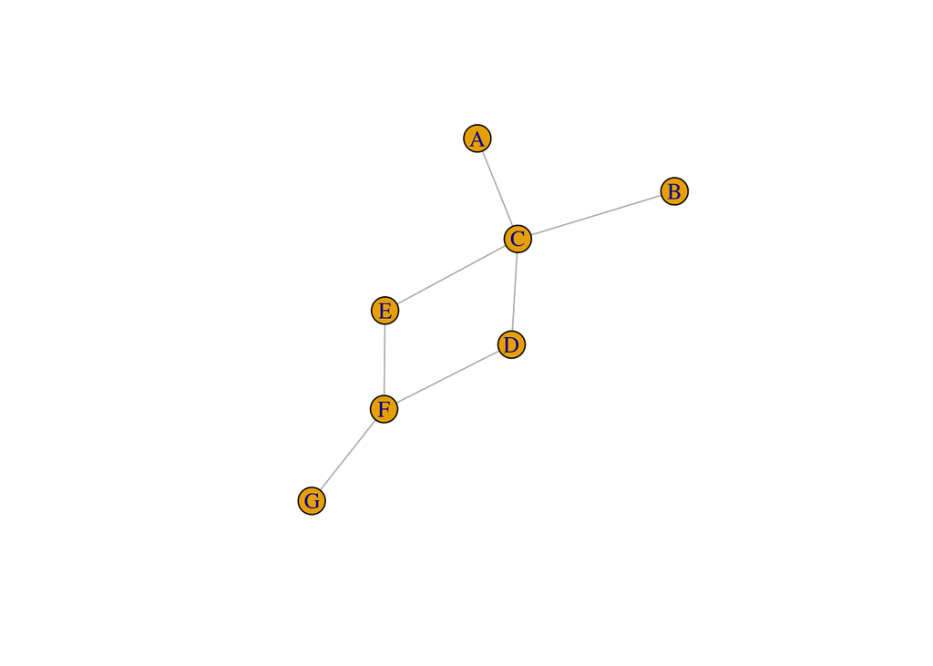